# Chapter 6 Exercises: Part 2

Caitlyn Ralph

4/1/2018

## Applied Exercises

### 8. In this exercise, we will generate simulated data, and will then use this data to perform best subset selection.

#### (a) Use the `rnorm()` function to generate a predictor X of length n = 100, as well as a noise vector ε of length n = 100.

```r
set.seed(1)
X <- rnorm(100)
e <- rnorm(100)
```

#### (b) Generate a response vector Y of length n = 100 according to the model

$$Y = \beta_0 + \beta_1X + \beta_2X^2 + \beta3X^3 + \epsilon$$
where $\beta_0\text{,}\hspace{0.5cm}\beta_1\text{,}\hspace{0.5cm}\beta_2{,}\hspace{0.5cm}\text{and}\hspace{0.5cm}\beta_3$ are constants of your choice.

I set $\beta_0$ to 10.

I set $\beta_1$ to 15.

I set $\beta_2$ to 20.

I set $\beta_3$ to 30.

```r
Y <- 10 + 15*X + 20*X^2 + 30*X^3 + e
```

#### (c) Use the `regsubsets()` function to perform best subset selection in order to choose the best model containing the predictors X, X2, . . . , X10. What is the best model obtained according to Cp, BIC, and adjusted R2? Show some plots to provide evidence for your answer, and report the coefficients of the best model obtained. Note you will need to use the `data.frame()` function to create a single data set containing both X and Y.

```r
library(leaps)
d <- data.frame(X,Y)
dim(d)
```

```
## [1] 100   2
```

```r
regfit.full <- regsubsets(Y~poly(X,10,raw=T), d,nvmax=10)
```

```r
reg.summary <- summary(regfit.full)
names(reg.summary)
```

```
## [1] "which"  "rsq"    "rss"    "adjr2"  "cp"     "bic"    "outmat" "obj"
```

```r
reg.summary$rsq
```

```
##  [1] 0.9462150 0.9937257 0.9999072 0.9999107 0.9999111 0.9999113 0.9999115
##  [8] 0.9999121 0.9999121 0.9999123
```

```r
reg.summary$cp
```

```
##  [1] 5.448560e+04 6.273183e+03 2.185943e+00 6.067483e-01 2.178201e+00
##  [6] 3.995581e+00 5.786906e+00 7.169409e+00 9.153558e+00 1.100000e+01
```

```r
reg.summary$bic
```

```
##  [1] -283.0657 -493.3145 -910.0734 -909.3425 -905.2114 -900.8090 -896.4359
##  [8] -892.5209 -887.9335 -883.5007
```

```r
reg.summary$adjr2
```

```
##  [1] 0.9456661 0.9935964 0.9999043 0.9999070 0.9999064 0.9999056 0.9999048
##  [8] 0.9999044 0.9999034 0.9999024
```

The $R^2$ monotonically increases with the number of variables.

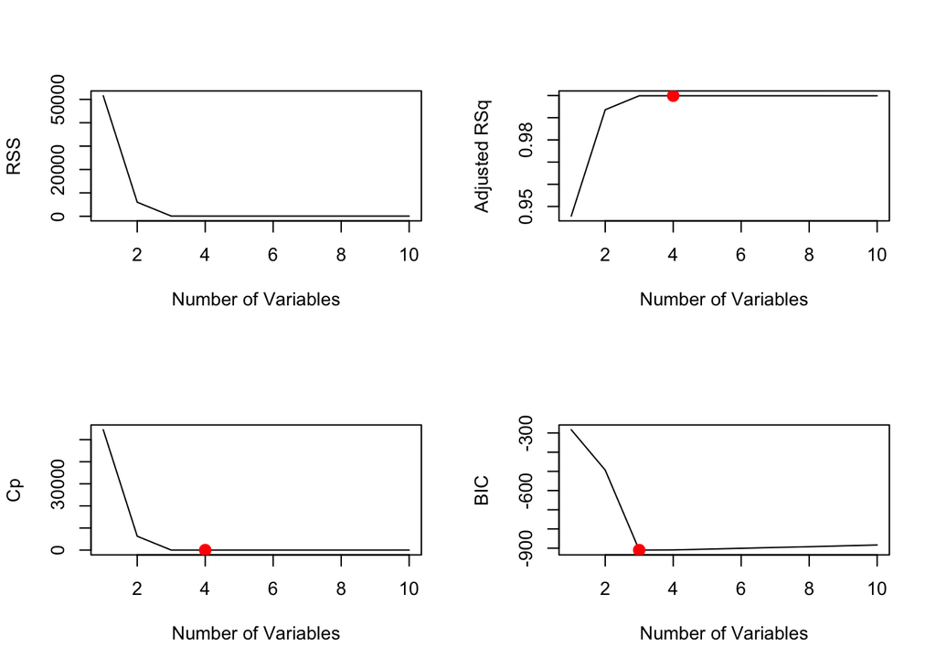

```r
par(mfrow=c(2,2))
plot(reg.summary$rss,xlab="Number of Variables",ylab="RSS",type="l")
plot(reg.summary$adjr2,xlab="Number of Variables",ylab="Adjusted RSq",type="l")
max_adjr2 <- which.max(reg.summary$adjr2)
points(max_adjr2, reg.summary$adjr2[max_adjr2], col="red",cex=2,pch=20)

plot(reg.summary$cp,xlab="Number of Variables",ylab="Cp",type="l")
min_cp <- which.min(reg.summary$cp)
points(min_cp, reg.summary$cp[min_cp], col="red",cex=2,pch=20)

plot(reg.summary$bic,xlab="Number of Variables",ylab="BIC",type="l")
min_bic <- which.min(reg.summary$bic)
points(min_bic,reg.summary$bic[min_bic],col="red",cex=2,pch=20)
```

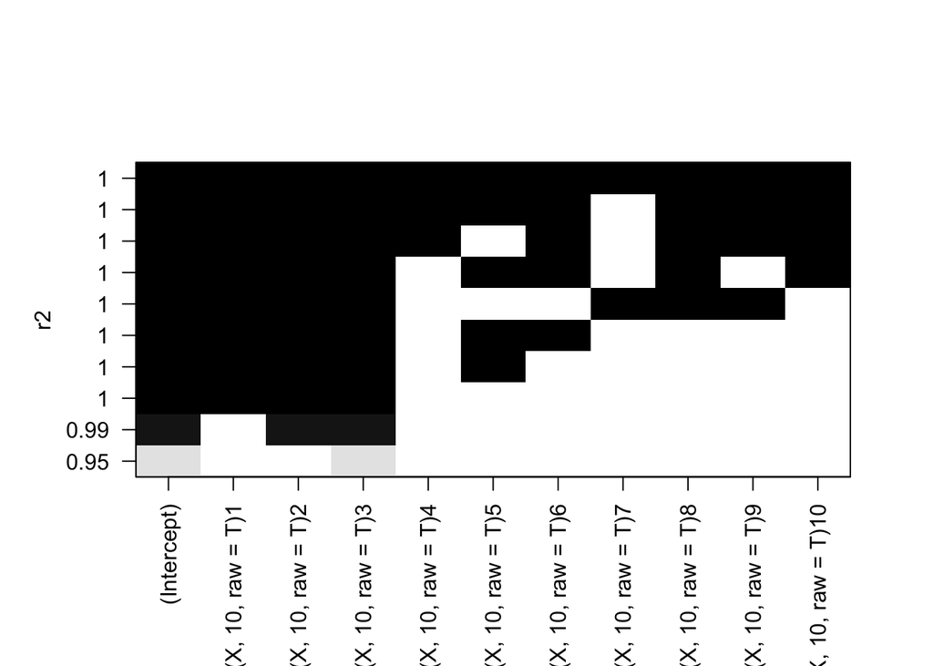

```r
plot(regfit.full,scale="r2")
```

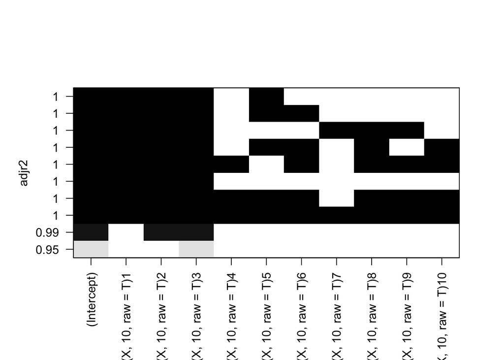

```r
plot(regfit.full,scale="adjr2")
```

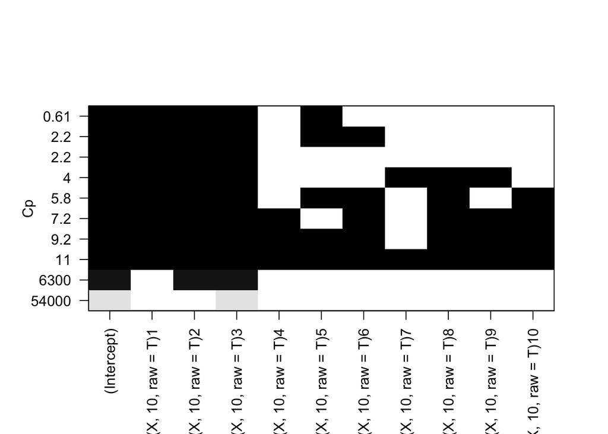

```r
plot(regfit.full,scale="Cp")
```

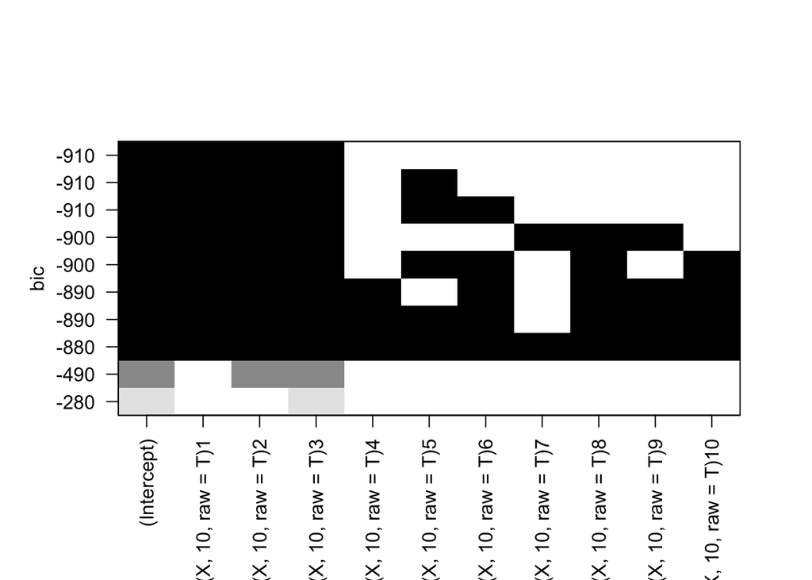

```r
plot(regfit.full,scale="bic")
```

```r
coef(regfit.full,3)
```

```
##           (Intercept) poly(X, 10, raw = T)1 poly(X, 10, raw = T)2
##              10.06151              14.97528              19.87621
## poly(X, 10, raw = T)3
##              30.01764
```

#### (d) Repeat (c), using forward stepwise selection and also using backwards stepwise selection. How does your answer compare to the results in (c)?

Forward stepwise selection:

```r
regfit.full <- regsubsets(Y~poly(X,10,raw=T), d,nvmax=10,method="forward")
```

```r
reg.summary <- summary(regfit.full)
names(reg.summary)
```

```
## [1] "which"  "rsq"    "rss"    "adjr2"  "cp"     "bic"    "outmat" "obj"
```

```r
reg.summary$rsq
```

```
##  [1] 0.9462150 0.9937257 0.9999072 0.9999107 0.9999111 0.9999113 0.9999113
##  [8] 0.9999114 0.9999115 0.9999123
```

```r
reg.summary$cp
```

```
##  [1] 5.448560e+04 6.273183e+03 2.185943e+00 6.067483e-01 2.178201e+00
##  [6] 4.062107e+00 6.016511e+00 7.958257e+00 9.784279e+00 1.100000e+01
```

```r
reg.summary$bic
```

```
##  [1] -283.0657 -493.3145 -910.0734 -909.3425 -905.2114 -900.7351 -896.1806
##  [8] -891.6401 -887.2285 -883.5007
```

```r
reg.summary$adjr2
```

```
##  [1] 0.9456661 0.9935964 0.9999043 0.9999070 0.9999064 0.9999055 0.9999045
##  [8] 0.9999036 0.9999027 0.9999024
```

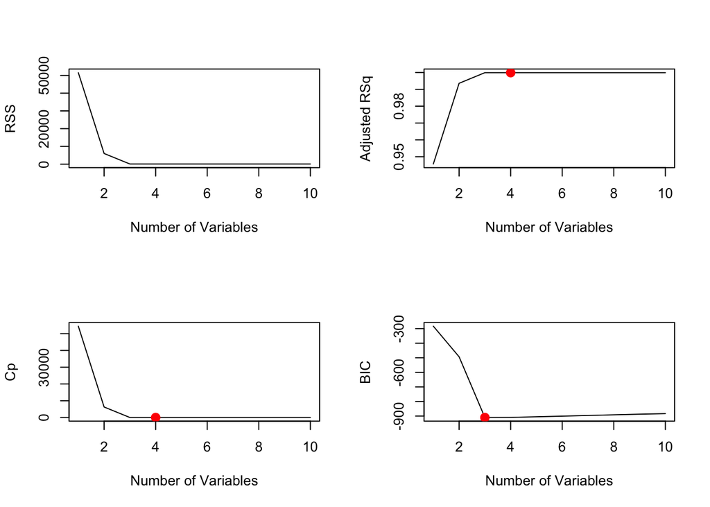

```r
par(mfrow=c(2,2))
plot(reg.summary$rss,xlab="Number of Variables",ylab="RSS",type="l")
plot(reg.summary$adjr2,xlab="Number of Variables",ylab="Adjusted RSq",type="l")
max_adjr2 <- which.max(reg.summary$adjr2)
points(max_adjr2, reg.summary$adjr2[max_adjr2], col="red",cex=2,pch=20)

plot(reg.summary$cp,xlab="Number of Variables",ylab="Cp",type="l")
min_cp <- which.min(reg.summary$cp)
points(min_cp, reg.summary$cp[min_cp], col="red",cex=2,pch=20)

plot(reg.summary$bic,xlab="Number of Variables",ylab="BIC",type="l")
min_bic <- which.min(reg.summary$bic)
points(min_bic,reg.summary$bic[min_bic],col="red",cex=2,pch=20)
```

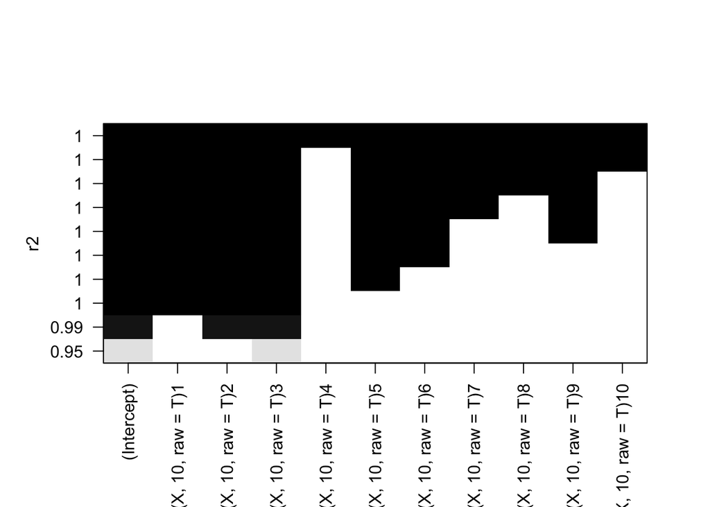

```r
plot(regfit.full,scale="r2")
```

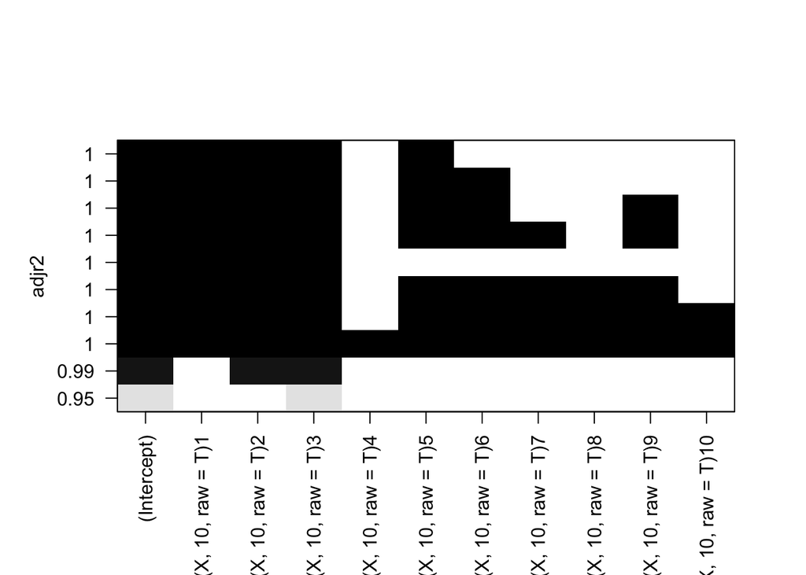

```r
plot(regfit.full,scale="adjr2")
```

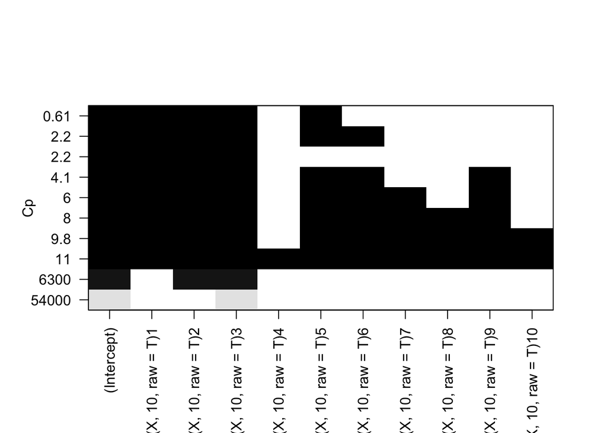

```r
plot(regfit.full,scale="Cp")
```

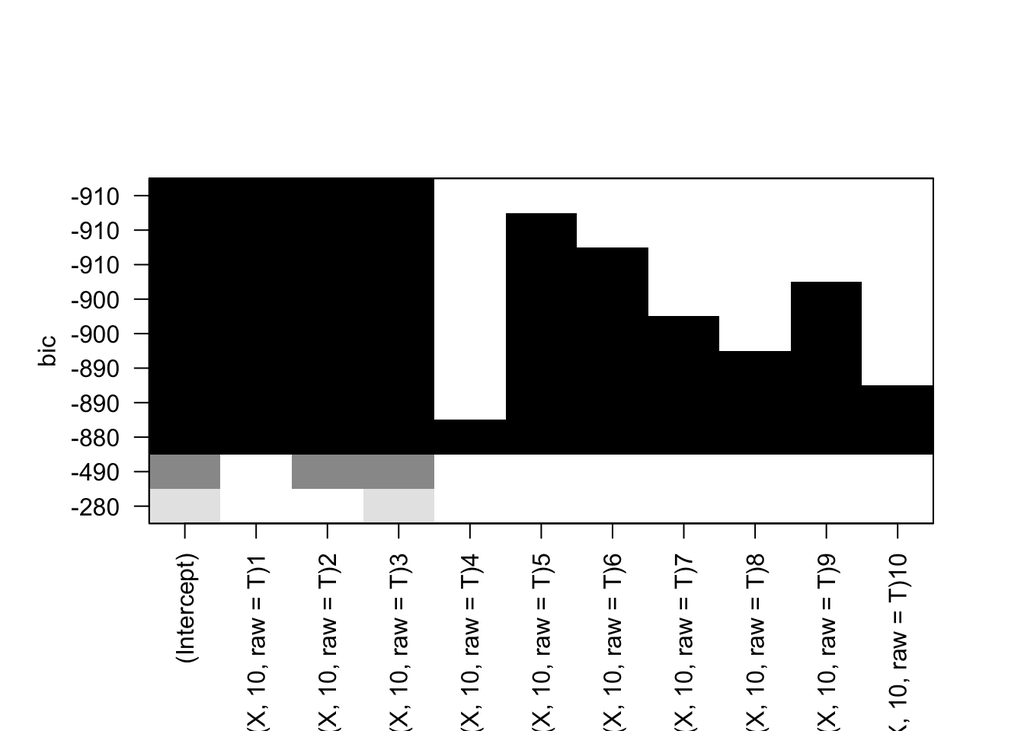

```r
plot(regfit.full,scale="bic")
```

```r
coef(regfit.full,3)
```

```
##           (Intercept) poly(X, 10, raw = T)1 poly(X, 10, raw = T)2
##              10.06151              14.97528              19.87621
## poly(X, 10, raw = T)3
##              30.01764
```

Backward stepwise selection:

```r
regfit.full <- regsubsets(Y~poly(X,10,raw=T), d,nvmax=10,method="backward")
```

```r
reg.summary <- summary(regfit.full)
names(reg.summary)
```

```
## [1] "which"  "rsq"    "rss"    "adjr2"  "cp"     "bic"    "outmat" "obj"
```

```r
reg.summary$rsq
```

```
##  [1] 0.9462150 0.9937257 0.9999072 0.9999103 0.9999106 0.9999109 0.9999114
##  [8] 0.9999121 0.9999121 0.9999123
```

```r
reg.summary$cp
```

```
##  [1] 5.448560e+04 6.273183e+03 2.185943e+00 9.808795e-01 2.731015e+00
##  [6] 4.418100e+00 5.925033e+00 7.169409e+00 9.153558e+00 1.100000e+01
```

```r
reg.summary$bic
```

```
##  [1] -283.0657 -493.3145 -910.0734 -908.9304 -904.6003 -900.3406 -896.2822
##  [8] -892.5209 -887.9335 -883.5007
```

```r
reg.summary$adjr2
```

```
##  [1] 0.9456661 0.9935964 0.9999043 0.9999066 0.9999058 0.9999052 0.9999046
##  [8] 0.9999044 0.9999034 0.9999024
```

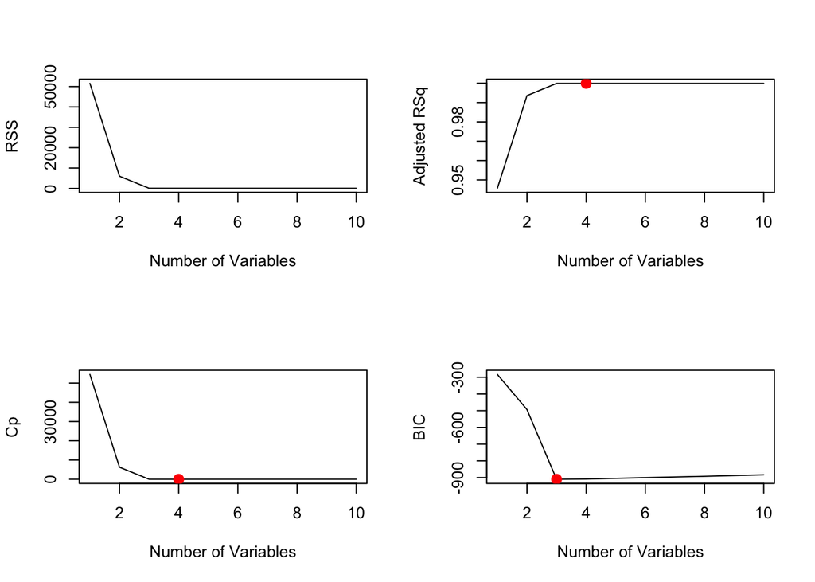

```r
par(mfrow=c(2,2))
plot(reg.summary$rss,xlab="Number of Variables",ylab="RSS",type="l")
plot(reg.summary$adjr2,xlab="Number of Variables",ylab="Adjusted RSq",type="l")
max_adjr2 <- which.max(reg.summary$adjr2)
points(max_adjr2, reg.summary$adjr2[max_adjr2], col="red",cex=2,pch=20)

plot(reg.summary$cp,xlab="Number of Variables",ylab="Cp",type="l")
min_cp <- which.min(reg.summary$cp)
points(min_cp, reg.summary$cp[min_cp], col="red",cex=2,pch=20)

plot(reg.summary$bic,xlab="Number of Variables",ylab="BIC",type="l")
min_bic <- which.min(reg.summary$bic)
points(min_bic,reg.summary$bic[min_bic],col="red",cex=2,pch=20)
```

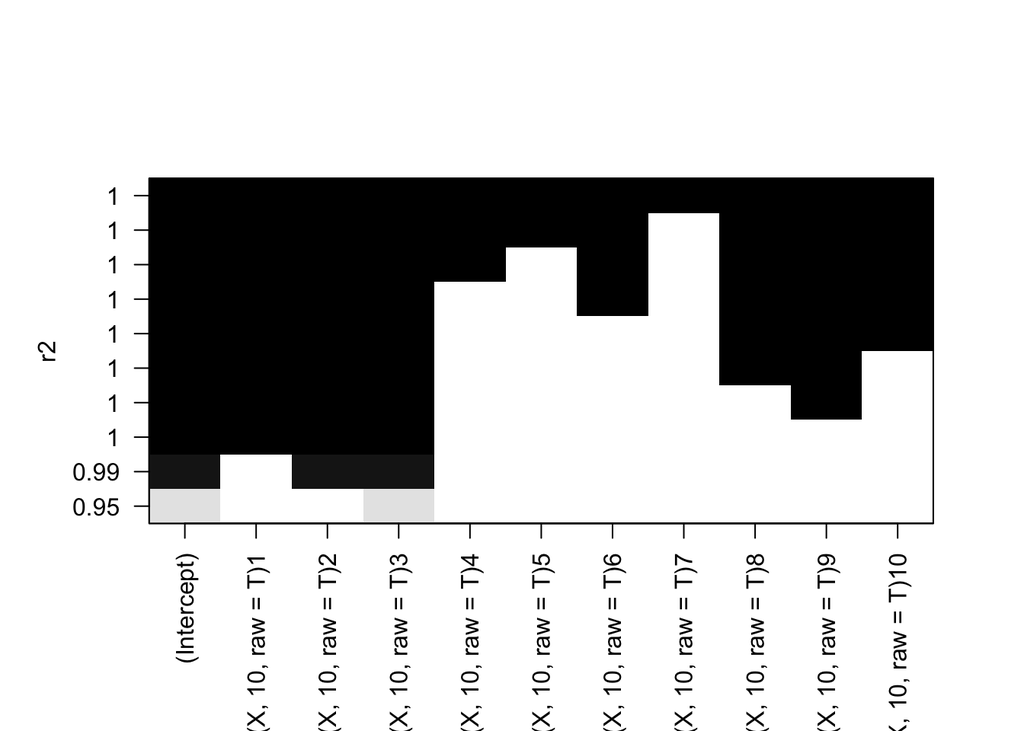

```r
plot(regfit.full,scale="r2")
```

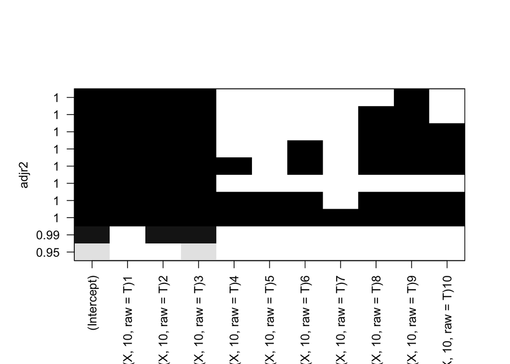

```r
plot(regfit.full,scale="adjr2")
```

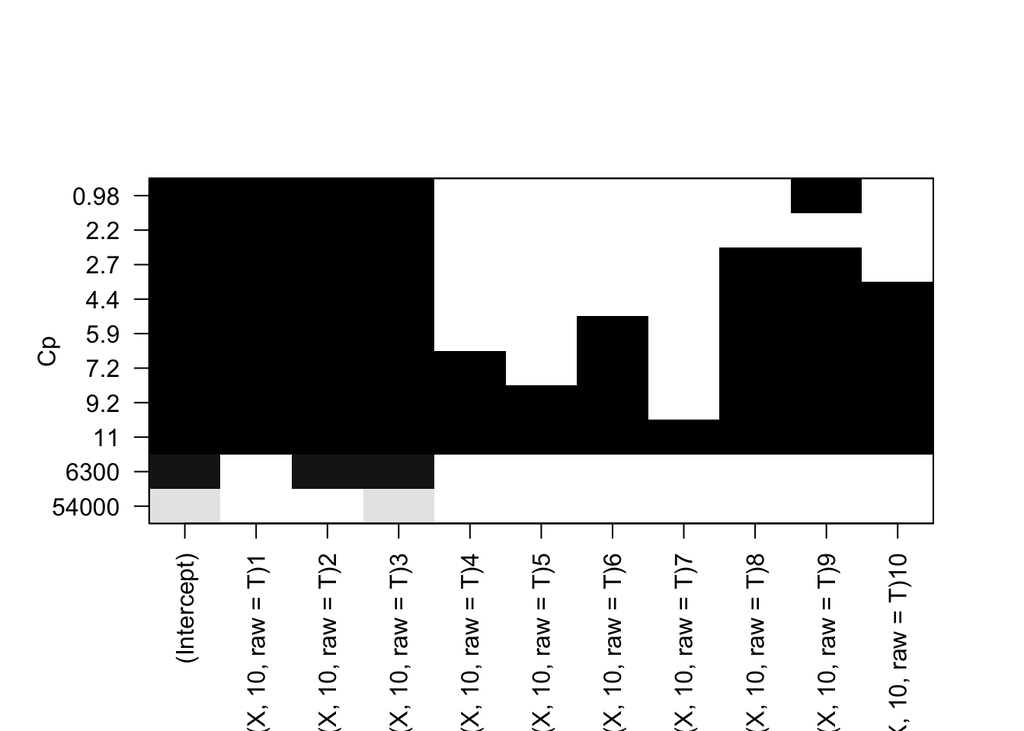

```r
plot(regfit.full,scale="Cp")
```

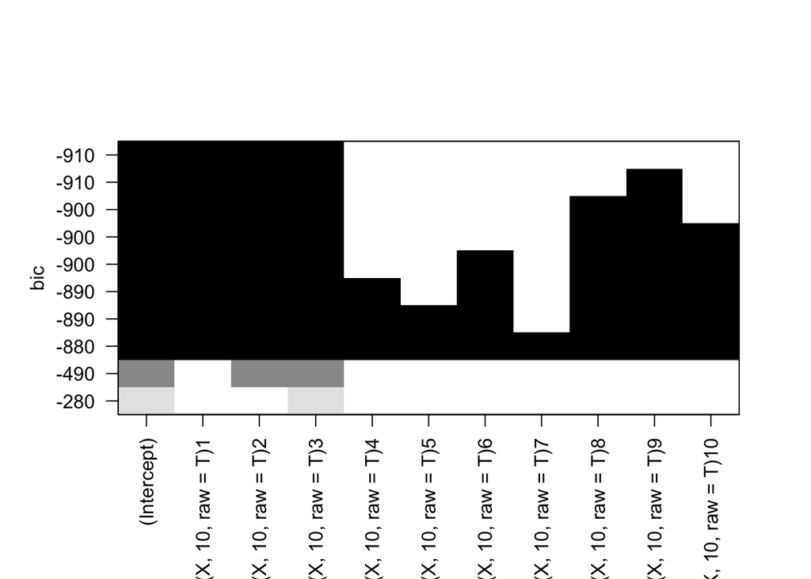

```r
plot(regfit.full,scale="bic")
```

```r
coef(regfit.full,3)
```

```
##           (Intercept) poly(X, 10, raw = T)1 poly(X, 10, raw = T)2
##              10.06151              14.97528              19.87621
## poly(X, 10, raw = T)3
##              30.01764
```

The results from the best subset selection appear to agree with the results from the forward stepwise selection and the backward stepwise selection.

#### (e) Now fit a lasso model to the simulated data, again using X,X2, . . . , X 10 as predictors. Use cross-validation to select the optimal value of λ. Create plots of the cross-validation error as a function of λ. Report the resulting coefficient estimates, and discuss the results obtained.

```r
x<-model.matrix(Y~poly(X,10,raw=T),d)[,-1]
y<-d$Y
```

```r
library(glmnet)
```

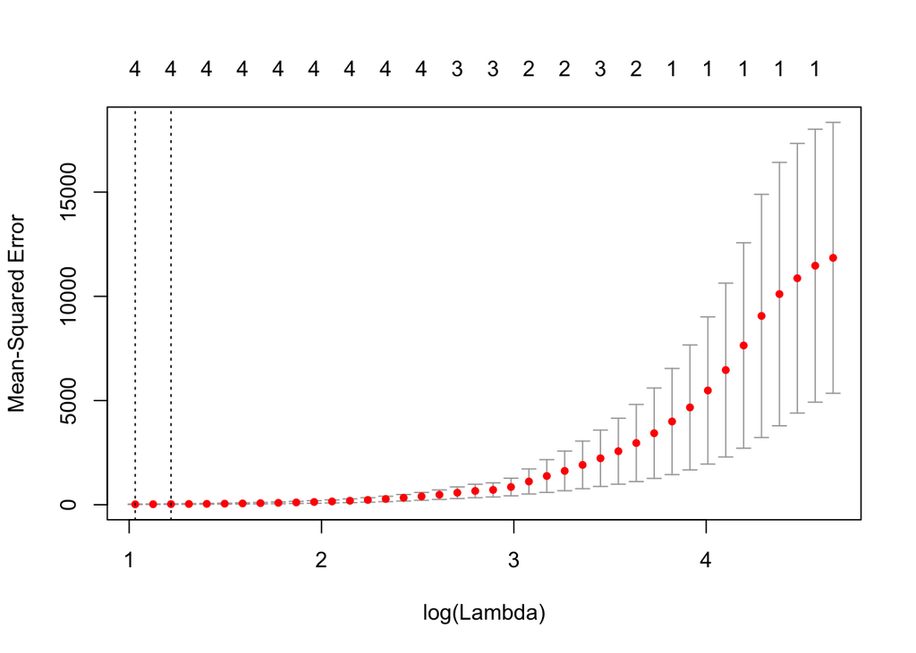

```r
grid=10^seq(10,-2,length=100)
lasso.mod=glmnet(x,y,alpha=1,lambda=grid)

set.seed(1)
train <- sample(1:nrow(x),nrow(x)/2)
test <- (-train)
y.test <- y[test]

set.seed(1)
cv.out <- cv.glmnet(x[train,],y[train],alpha=1)
plot(cv.out)
```

```r
bestlam <- cv.out$lambda.min
bestlam
```

```
## [1] 2.805251
```

```r
lasso.pred <- predict(lasso.mod,s=bestlam,newx=x[test,])
mean((lasso.pred-y.test)^2)
```

```
## [1] 11.41396
```

```r
out <- glmnet(x,y,alpha=1)
predict(out,type="coefficients",s=bestlam)
```

```
## 11 x 1 sparse Matrix of class "dgCMatrix"
##                               1
## (Intercept)            12.08442
## poly(X, 10, raw = T)1  12.75213
## poly(X, 10, raw = T)2  17.74409
## poly(X, 10, raw = T)3  29.76771
## poly(X, 10, raw = T)4   .
## poly(X, 10, raw = T)5   .
## poly(X, 10, raw = T)6   .
## poly(X, 10, raw = T)7   .
## poly(X, 10, raw = T)8   .
## poly(X, 10, raw = T)9   .
## poly(X, 10, raw = T)10  .
```

Similar to the results found with subset selection, the lasso selects up to the 3-variable model.

#### (f) Now generate a response vector Y according to the model

$$Y = \beta_0 + \beta_7X^7 + \epsilon$$

and perform best subset selection and the lasso. Discuss the results obtained.

I set $\beta_7$ to 25.

```r
Y <- 10 + 25*X^7 + e
```

```r
library(leaps)
d <- data.frame(X,Y)
dim(d)
```

```
## [1] 100   2
```

```r
regfit.full <- regsubsets(Y~poly(X,10,raw=T), d,nvmax=10)
```

```r
reg.summary <- summary(regfit.full)
names(reg.summary)
```

```
## [1] "which"  "rsq"    "rss"    "adjr2"  "cp"     "bic"    "outmat" "obj"
```

```r
reg.summary$rsq
```

```
##  [1] 0.9999996 0.9999996 0.9999996 0.9999996 0.9999996 0.9999996 0.9999996
##  [8] 0.9999996 0.9999996 0.9999996
```

```r
reg.summary$cp
```

```
##  [1] -0.05835158 -0.57457577 -0.26264076  0.73888307  2.40063344
##  [6]  3.84493124  5.81405698  7.18226563  9.16504068 11.00000000
```

```r
reg.summary$bic
```

```
##  [1] -1465.312 -1463.364 -1460.582 -1457.072 -1452.840 -1448.851 -1444.280
##  [8] -1440.381 -1435.795 -1431.375
```

```r
reg.summary$adjr2
```

```
##  [1] 0.9999996 0.9999996 0.9999996 0.9999996 0.9999996 0.9999996 0.9999996
##  [8] 0.9999996 0.9999996 0.9999996
```

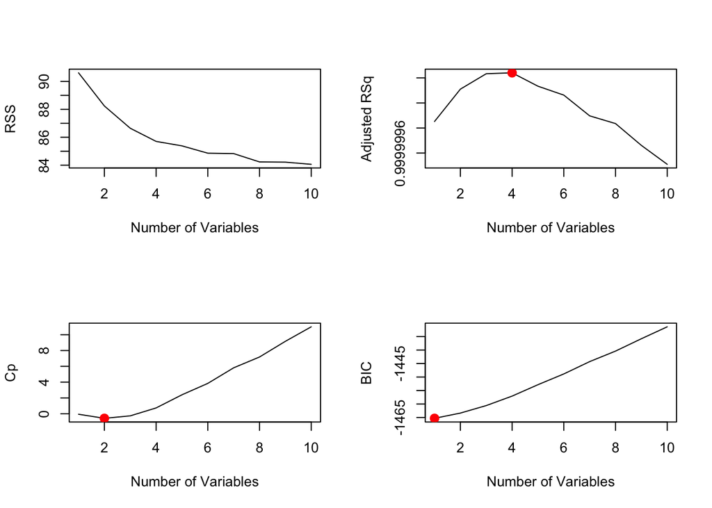

```r
par(mfrow=c(2,2))
plot(reg.summary$rss,xlab="Number of Variables",ylab="RSS",type="l")
plot(reg.summary$adjr2,xlab="Number of Variables",ylab="Adjusted RSq",type="l")
max_adjr2 <- which.max(reg.summary$adjr2)
points(max_adjr2, reg.summary$adjr2[max_adjr2], col="red",cex=2,pch=20)

plot(reg.summary$cp,xlab="Number of Variables",ylab="Cp",type="l")
min_cp <- which.min(reg.summary$cp)
points(min_cp, reg.summary$cp[min_cp], col="red",cex=2,pch=20)

plot(reg.summary$bic,xlab="Number of Variables",ylab="BIC",type="l")
min_bic <- which.min(reg.summary$bic)
points(min_bic,reg.summary$bic[min_bic],col="red",cex=2,pch=20)
```

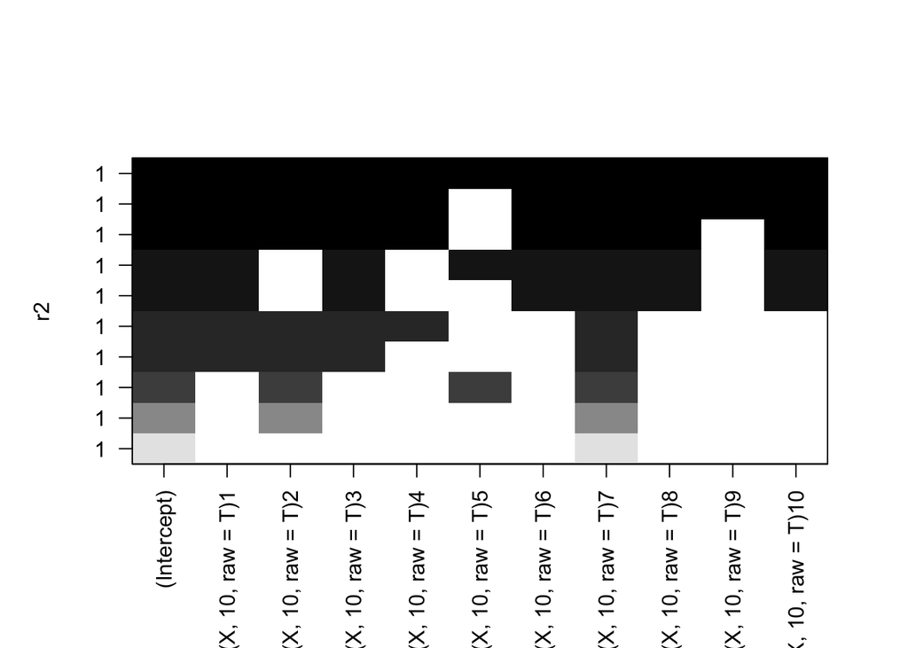

```r
plot(regfit.full,scale="r2")
```

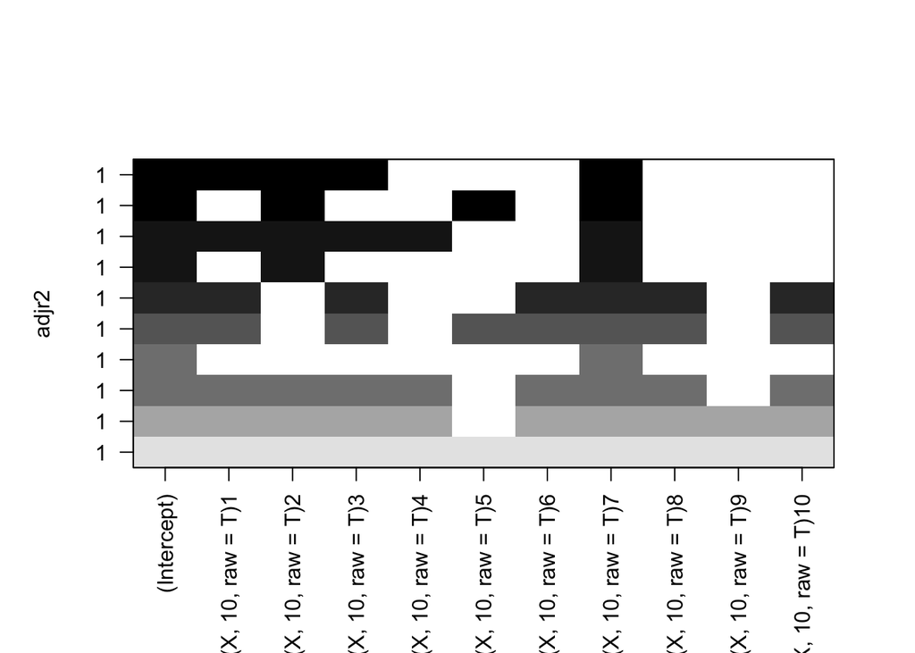

```r
plot(regfit.full,scale="adjr2")
```

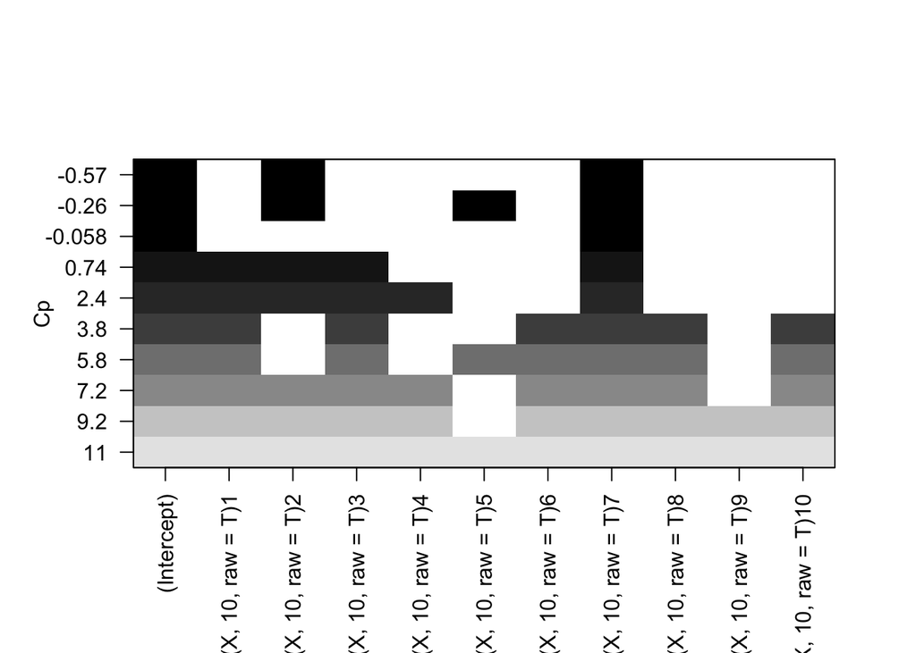

```r
plot(regfit.full,scale="Cp")
```

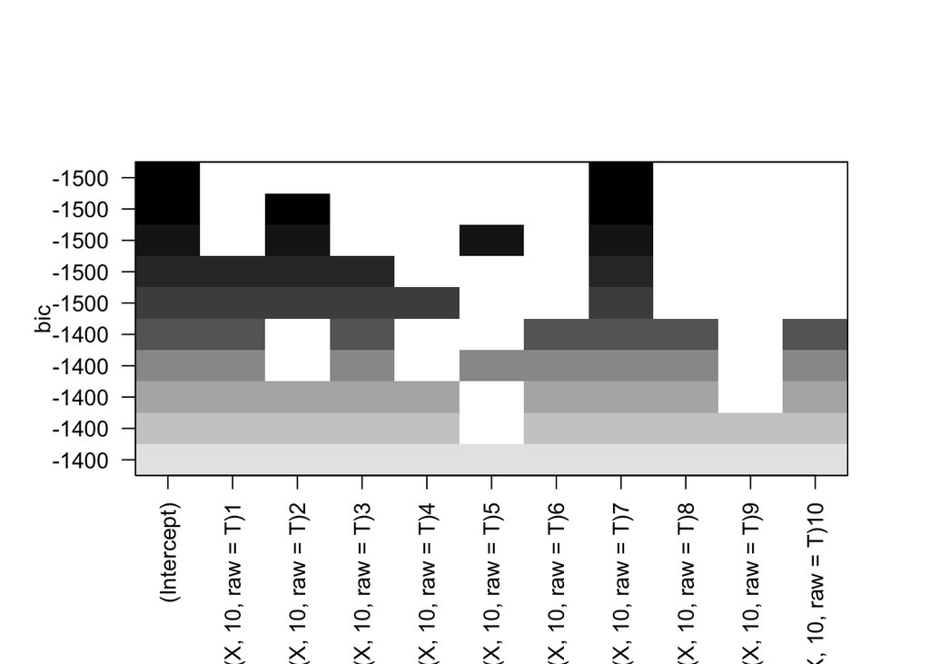

```r
plot(regfit.full,scale="bic")
```

```r
coef(regfit.full,2)
```

```
##           (Intercept) poly(X, 10, raw = T)2 poly(X, 10, raw = T)7
##            10.0704904            -0.1417084            25.0015552
```

```r
x<-model.matrix(Y~poly(X,10,raw=T),d)[,-1]
y<-d$Y
```

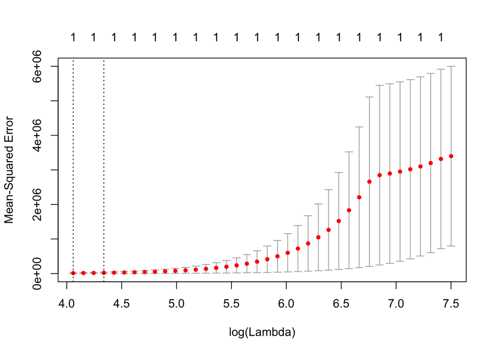

```r
library(glmnet)
grid=10^seq(10,-2,length=100)
lasso.mod=glmnet(x,y,alpha=1,lambda=grid)

set.seed(1)
train <- sample(1:nrow(x),nrow(x)/2)
test <- (-train)
y.test <- y[test]

set.seed(1)
cv.out <- cv.glmnet(x[train,],y[train],alpha=1)
plot(cv.out)
```

```r
bestlam <- cv.out$lambda.min
bestlam
```

```
## [1] 57.90443
```

```r
lasso.pred <- predict(lasso.mod,s=bestlam,newx=x[test,])
mean((lasso.pred-y.test)^2)
```

```
## [1] 1863.952
```

```r
out <- glmnet(x,y,alpha=1)
predict(out,type="coefficients",s=bestlam)
```

```
## 11 x 1 sparse Matrix of class "dgCMatrix"
##                               1
## (Intercept)            13.99098
## poly(X, 10, raw = T)1   .
## poly(X, 10, raw = T)2   .
## poly(X, 10, raw = T)3   .
## poly(X, 10, raw = T)4   .
## poly(X, 10, raw = T)5   .
## poly(X, 10, raw = T)6   .
## poly(X, 10, raw = T)7  24.04539
## poly(X, 10, raw = T)8   .
## poly(X, 10, raw = T)9   .
## poly(X, 10, raw = T)10  .
```

As compared to the first part of this question, the results in this section are much harder to interpret. The best subset selection seems to show that the a two-variable model may work well, but the lasso is putting everything to zero except the 7th variable. Using the model with the lower degrees seemed to have better, more consistent results.

### 9. In this exercise, we will predict the number of applications received using the other variables in the `College` data set.

#### (a) Split the data set into a training set and a test set.

```r
college <- read.csv("College.csv", header=T, na.strings="?")
rownames(college)=college[,1]
college <- college[,-1]
attach(college)

mean(Apps)
```

```
## [1] 3001.638
```

```r
train <- (Apps<3000)
test <- !train
college.train <- college[train,]
college.test <- college[test,]
Apps.test=Apps[test]
```

#### (b) Fit a linear model using least squares on the training set, and report the test error obtained.

```r
lm.fit=lm(Apps~.,data=college,subset=train)
lm.fit
```

```
##
## Call:
## lm(formula = Apps ~ ., data = college, subset = train)
##
## Coefficients:
## (Intercept)   PrivateYes       Accept       Enroll    Top10perc
##  -3.271e+02   -9.051e+01    1.275e+00   -3.125e-01    4.996e+00
##   Top25perc  F.Undergrad  P.Undergrad     Outstate   Room.Board
##  -7.891e-03    2.359e-02    2.395e-02   -5.522e-03    3.238e-02
##       Books     Personal          PhD     Terminal    S.F.Ratio
##   9.679e-02    3.255e-03    9.532e-02   -2.009e-01    6.254e+00
## perc.alumni       Expend    Grad.Rate
##  -4.529e-01    9.219e-03    1.397e+00
```

```r
lm.pred=predict(lm.fit,college.test)
mean(lm.pred != Apps.test)
```

```
## [1] 1
```

#### (c) Fit a ridge regression model on the training set, with λ chosen by cross-validation. Report the test error obtained.

```r
x<-model.matrix(Apps~.,college)[,-1]
y<-college$Apps
```

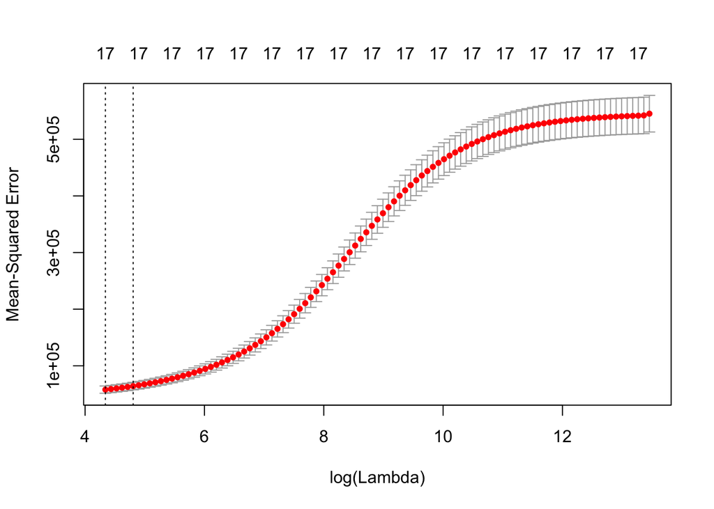

```r
library(glmnet)
grid=10^seq(10,-2,length=100)
ridge.mod=glmnet(x,y,alpha=0,lambda=grid)

set.seed(1)
cv.out <- cv.glmnet(x[train,],y[train],alpha=0)
plot(cv.out)
```

```r
bestlam <- cv.out$lambda.min
bestlam
```

```
## [1] 76.70771
```

```r
ridge.pred <- predict(ridge.mod,s=bestlam,newx=x[test,])
mean((ridge.pred-y.test)^2)
```

```
## [1] 73169044
```

```r
out <- glmnet(x,y,alpha=0)
predict(out,type="coefficients",s=bestlam)
```

```
## 18 x 1 sparse Matrix of class "dgCMatrix"
##                         1
## (Intercept) -1.468326e+03
## PrivateYes  -5.278781e+02
## Accept       1.004588e+00
## Enroll       4.313442e-01
## Top10perc    2.580619e+01
## Top25perc    5.501092e-01
## F.Undergrad  7.258520e-02
## P.Undergrad  2.420595e-02
## Outstate    -2.407454e-02
## Room.Board   1.987732e-01
## Books        1.285477e-01
## Personal    -8.146130e-03
## PhD         -4.028284e+00
## Terminal    -4.811071e+00
## S.F.Ratio    1.302180e+01
## perc.alumni -8.544783e+00
## Expend       7.589013e-02
## Grad.Rate    1.126699e+01
```

#### (d) Fit a lasso model on the training set, with λ chosen by cross- validation. Report the test error obtained, along with the number of non-zero coefficient estimates.

```r
x<-model.matrix(Apps~.,college)[,-1]
y<-college$Apps
```

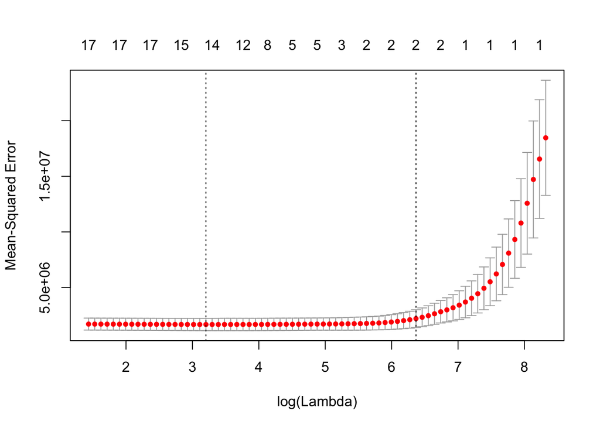

```r
library(glmnet)
grid=10^seq(10,-2,length=100)
lasso.mod=glmnet(x,y,alpha=1,lambda=grid)

set.seed(1)
train <- sample(1:nrow(x),nrow(x)/2)
test <- (-train)
y.test <- y[test]

set.seed(1)
cv.out <- cv.glmnet(x[train,],y[train],alpha=1)
plot(cv.out)
```

```r
bestlam <- cv.out$lambda.min
bestlam
```

```
## [1] 24.62086
```

```r
lasso.pred <- predict(lasso.mod,s=bestlam,newx=x[test,])
mean((lasso.pred-y.test)^2)
```

```
## [1] 953321.5
```

```r
out <- glmnet(x,y,alpha=1)
predict(out,type="coefficients",s=bestlam)
```

```
## 18 x 1 sparse Matrix of class "dgCMatrix"
##                         1
## (Intercept) -633.79486239
## PrivateYes  -408.83296398
## Accept         1.43685453
## Enroll        -0.14165984
## Top10perc     31.44776265
## Top25perc     -0.86602702
## F.Undergrad    .
## P.Undergrad    0.01510238
## Outstate      -0.05341522
## Room.Board     0.12058999
## Books          .
## Personal       .
## PhD           -5.14304236
## Terminal      -3.36388533
## S.F.Ratio      2.81663269
## perc.alumni   -1.05175494
## Expend         0.06842417
## Grad.Rate      4.71254347
```

There are 14 non-zero coefficients.

#### (e) Fit a PCR model on the training set, with M chosen by cross- validation. Report the test error obtained, along with the value of M selected by cross-validation.

```r
library(pls)
set.seed(2)
pcr.fit <- pcr(Apps~.,data=college,scale=TRUE,validation="CV")
summary(pcr.fit)
```

```
## Data:    X dimension: 777 17
##  Y dimension: 777 1
## Fit method: svdpc
## Number of components considered: 17
##
## VALIDATION: RMSEP
## Cross-validated using 10 random segments.
##        (Intercept)  1 comps  2 comps  3 comps  4 comps  5 comps  6 comps
## CV            3873     3837     2022     2028     1796     1584     1579
## adjCV         3873     3837     2021     2028     1733     1576     1576
##        7 comps  8 comps  9 comps  10 comps  11 comps  12 comps  13 comps
## CV        1575     1539     1494      1484      1488      1488      1490
## adjCV     1571     1533     1492      1482      1485      1485      1488
##        14 comps  15 comps  16 comps  17 comps
## CV         1489      1450      1162      1131
## adjCV      1486      1437      1156      1125
##
## TRAINING: % variance explained
##       1 comps  2 comps  3 comps  4 comps  5 comps  6 comps  7 comps
## X      31.670    57.30    64.30    69.90    75.39    80.38    83.99
## Apps    2.316    73.06    73.07    82.08    84.08    84.11    84.32
##       8 comps  9 comps  10 comps  11 comps  12 comps  13 comps  14 comps
## X       87.40    90.50     92.91     95.01     96.81      97.9     98.75
## Apps    85.18    85.88     86.06     86.06     86.10      86.1     86.13
##       15 comps  16 comps  17 comps
## X        99.36     99.84    100.00
## Apps     90.32     92.52     92.92
```

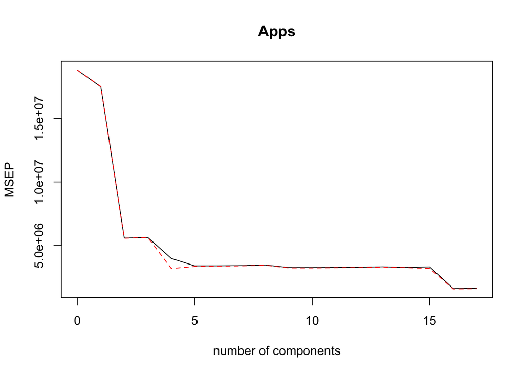

```r
set.seed(1)
pcr.fit <- pcr(Apps~., data=college, subset=train,scale=TRUE, validation="CV")
validationplot(pcr.fit,val.type="MSEP")
```

```r
pcr.pred <- predict(pcr.fit,x[test,],ncomp=12)
mean((pcr.pred-y.test)^2)
```

```
## [1] 1509435
```

```r
pcr.fit <- pcr(y~x,scale=TRUE,ncomp=12)
summary(pcr.fit)
```

```
## Data:    X dimension: 777 17
##  Y dimension: 777 1
## Fit method: svdpc
## Number of components considered: 12
## TRAINING: % variance explained
##    1 comps  2 comps  3 comps  4 comps  5 comps  6 comps  7 comps  8 comps
## X   31.670    57.30    64.30    69.90    75.39    80.38    83.99    87.40
## y    2.316    73.06    73.07    82.08    84.08    84.11    84.32    85.18
##    9 comps  10 comps  11 comps  12 comps
## X    90.50     92.91     95.01     96.81
## y    85.88     86.06     86.06     86.10
```

#### (f) Fit a PLS model on the training set, with M chosen by cross- validation. Report the test error obtained, along with the value of M selected by cross-validation.

```r
set.seed(1)
pls.fit <- plsr(Apps~., data=college, subset=train, scale=TRUE, validation="CV")
summary(pls.fit)
```

```
## Data:    X dimension: 388 17
##  Y dimension: 388 1
## Fit method: kernelpls
## Number of components considered: 17
##
## VALIDATION: RMSEP
## Cross-validated using 10 random segments.
##        (Intercept)  1 comps  2 comps  3 comps  4 comps  5 comps  6 comps
## CV            4335     2176     1893     1725     1613     1406     1312
## adjCV         4335     2171     1884     1715     1578     1375     1295
##        7 comps  8 comps  9 comps  10 comps  11 comps  12 comps  13 comps
## CV        1297     1285     1280      1278      1279      1282      1281
## adjCV     1281     1271     1267      1265      1266      1269      1268
##        14 comps  15 comps  16 comps  17 comps
## CV         1281      1281      1281      1281
## adjCV      1267      1267      1268      1268
##
## TRAINING: % variance explained
##       1 comps  2 comps  3 comps  4 comps  5 comps  6 comps  7 comps
## X       26.91    43.08    63.26    65.16    68.50    73.75    76.10
## Apps    76.64    83.93    87.14    91.90    93.49    93.85    93.91
##       8 comps  9 comps  10 comps  11 comps  12 comps  13 comps  14 comps
## X       79.03    81.76     85.41     89.03     91.38     93.31     95.43
## Apps    93.94    93.96     93.96     93.96     93.97     93.97     93.97
##       15 comps  16 comps  17 comps
## X        97.41     98.78    100.00
## Apps     93.97     93.97     93.97
```

```r
pls.pred <- predict(pls.fit,x[test,],ncomp=10)
mean((pls.pred-y.test)^2)
```

```
## [1] 1134531
```

```r
pls.fit=plsr(Apps~.,data=college,scale=TRUE,ncomp=10)
summary(pls.fit)
```

```
## Data:    X dimension: 777 17
##  Y dimension: 777 1
## Fit method: kernelpls
## Number of components considered: 10
## TRAINING: % variance explained
##       1 comps  2 comps  3 comps  4 comps  5 comps  6 comps  7 comps
## X       25.76    40.33    62.59    64.97    66.87    71.33    75.39
## Apps    78.01    85.14    87.67    90.73    92.63    92.72    92.77
##       8 comps  9 comps  10 comps
## X       79.37    82.36     85.04
## Apps    92.82    92.87     92.89
```

### 11. We will now try to predict per capita crime rate in the Boston data set.

#### (a) Try out some of the regression methods explored in this chapter, such as best subset selection, the lasso, ridge regression, and PCR. Present and discuss results for the approaches that you consider.

Since Jennifer did the lasso and PCR, I’m going to try ridge regression and best subset selection.

First, best subset selection:

```r
library(leaps)
library(MASS)
attach(Boston)
regfit.full <- regsubsets(crim~.,Boston)
```

```r
reg.summary <- summary(regfit.full)
names(reg.summary)
```

```
## [1] "which"  "rsq"    "rss"    "adjr2"  "cp"     "bic"    "outmat" "obj"
```

```r
reg.summary$rsq
```

```
## [1] 0.3912567 0.4207965 0.4286123 0.4334892 0.4392738 0.4440173 0.4476594
## [8] 0.4504606
```

```r
reg.summary$cp
```

```
## [1] 46.548369 21.929562 16.886597 14.492012 11.279399  9.004924  7.722956
## [8]  7.198756
```

```r
reg.summary$bic
```

```
## [1] -238.7044 -257.6477 -258.2957 -256.4064 -255.3732 -253.4454 -250.5445
## [8] -246.8906
```

```r
reg.summary$adjr2
```

```
## [1] 0.3900489 0.4184935 0.4251977 0.4289661 0.4336665 0.4373321 0.4398956
## [8] 0.4416149
```

For best subset selection, I am going to indirectly estimate the test error using the Cp, bic, and adjr2.

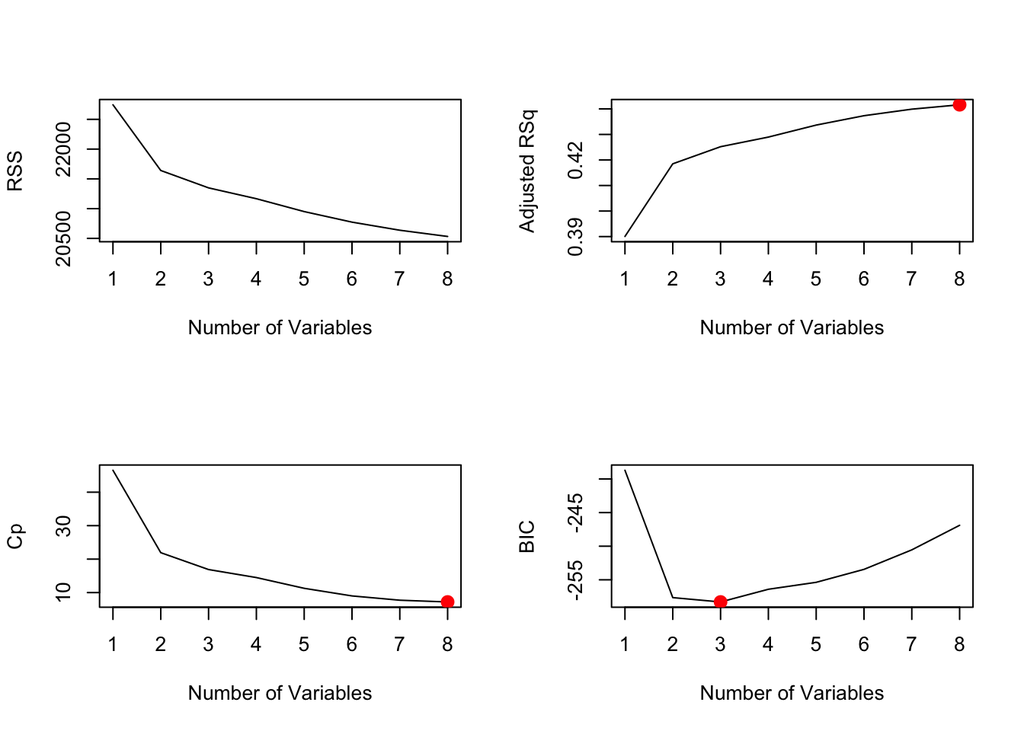

```r
par(mfrow=c(2,2))
plot(reg.summary$rss,xlab="Number of Variables",ylab="RSS",type="l")
plot(reg.summary$adjr2,xlab="Number of Variables",ylab="Adjusted RSq",type="l")
max_adjr2 <- which.max(reg.summary$adjr2)
points(max_adjr2, reg.summary$adjr2[max_adjr2], col="red",cex=2,pch=20)

plot(reg.summary$cp,xlab="Number of Variables",ylab="Cp",type="l")
min_cp <- which.min(reg.summary$cp)
points(min_cp, reg.summary$cp[min_cp], col="red",cex=2,pch=20)

plot(reg.summary$bic,xlab="Number of Variables",ylab="BIC",type="l")
min_bic <- which.min(reg.summary$bic)
points(min_bic,reg.summary$bic[min_bic],col="red",cex=2,pch=20)
```

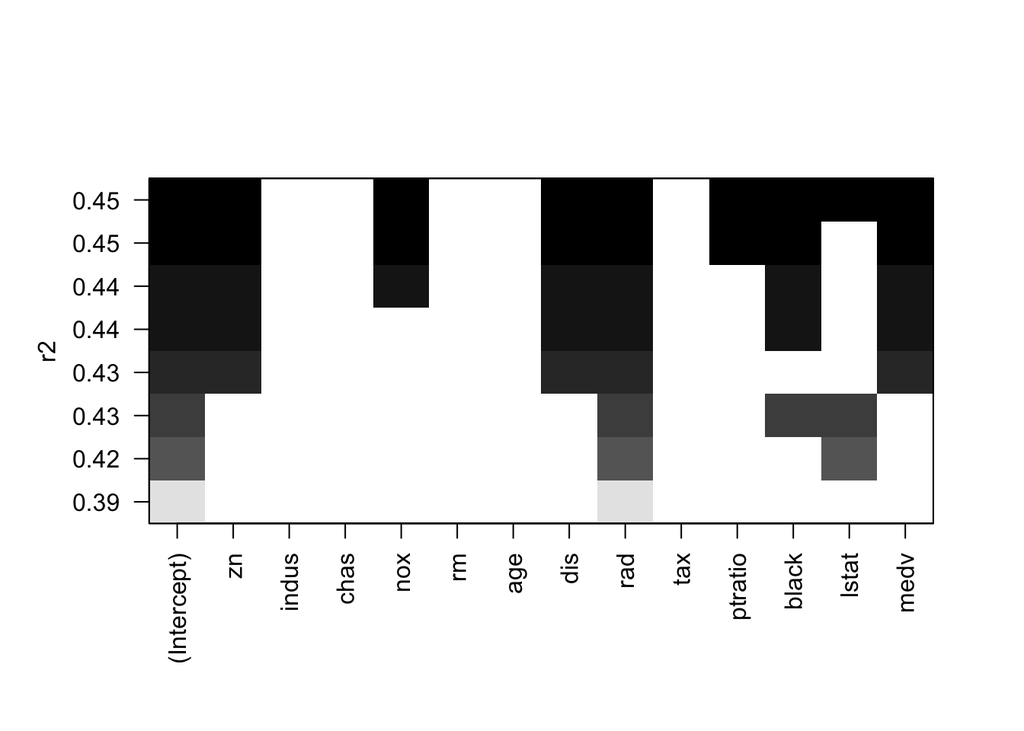

```r
plot(regfit.full,scale="r2")
```

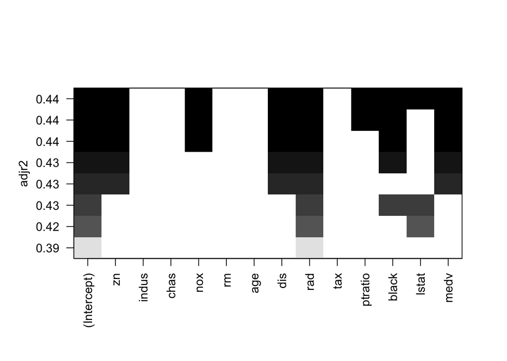

```r
plot(regfit.full,scale="adjr2")
```

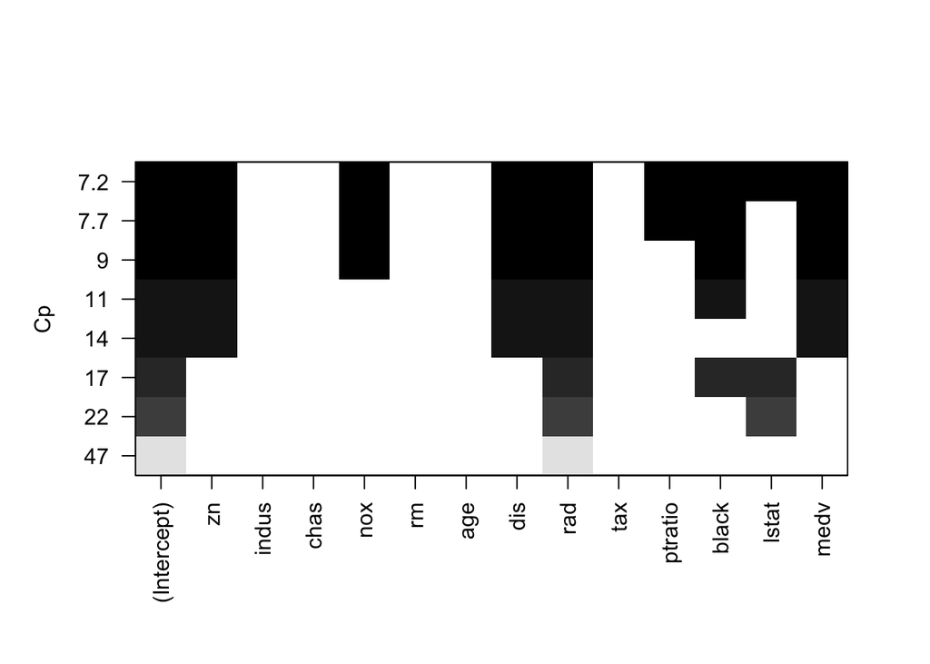

```r
plot(regfit.full,scale="Cp")
```

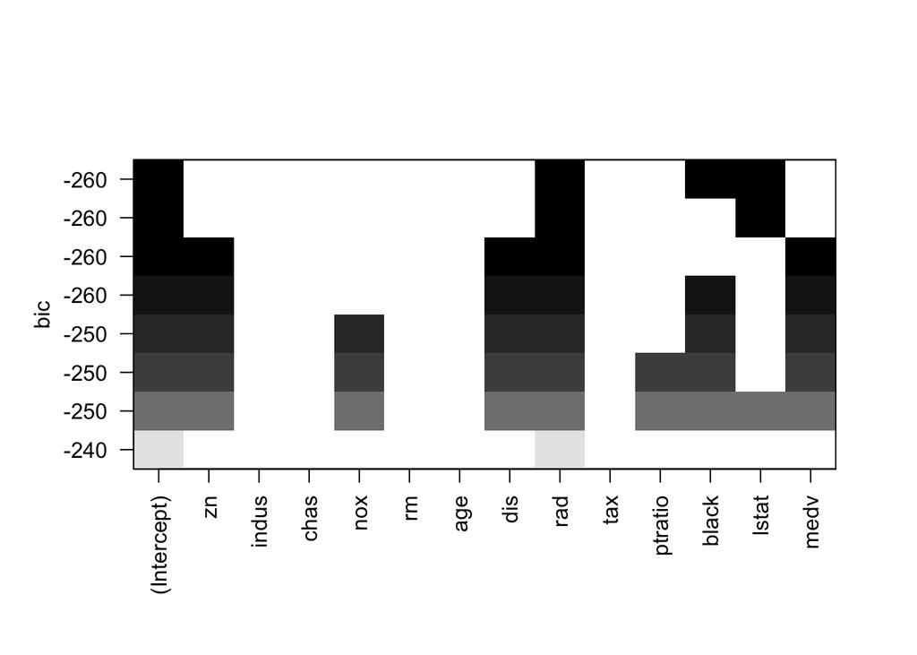

```r
plot(regfit.full,scale="bic")
```

Two of the three measures showed an 8-variable as best. bic showed the 3-variable model as best. Therefore, I’m instead going to directly estimate the test error using cross validation (code help from: http://uc-r.github.io/model_selection).

```r
k <- 10
set.seed(1)
folds <- sample(1:k, nrow(Boston), replace=TRUE)
cv_errors <- matrix(NA, k, 13, dimnames = list(NULL,paste(1:13)))
```

```r
predict.regsubsets <- function(object, newdata, id, ...) {
  form <- as.formula(object$call[[2]])
  mat <- model.matrix(form, newdata)
  coefi <- coef(object, id = id)
  xvars <- names(coefi)
  mat[, xvars] %*% coefi
  }
```

```r
for(j in 1:k) {
  best_subset <- regsubsets(crim~.,Boston[folds != j, ], nvmax=13)

  for (i in 1:13) {
    pred_x <- predict.regsubsets(best_subset, Boston[folds == j,], id=i)
    cv_errors[j,i] <- mean((Boston$crim[folds==j] - pred_x)^2)
  }
}
```

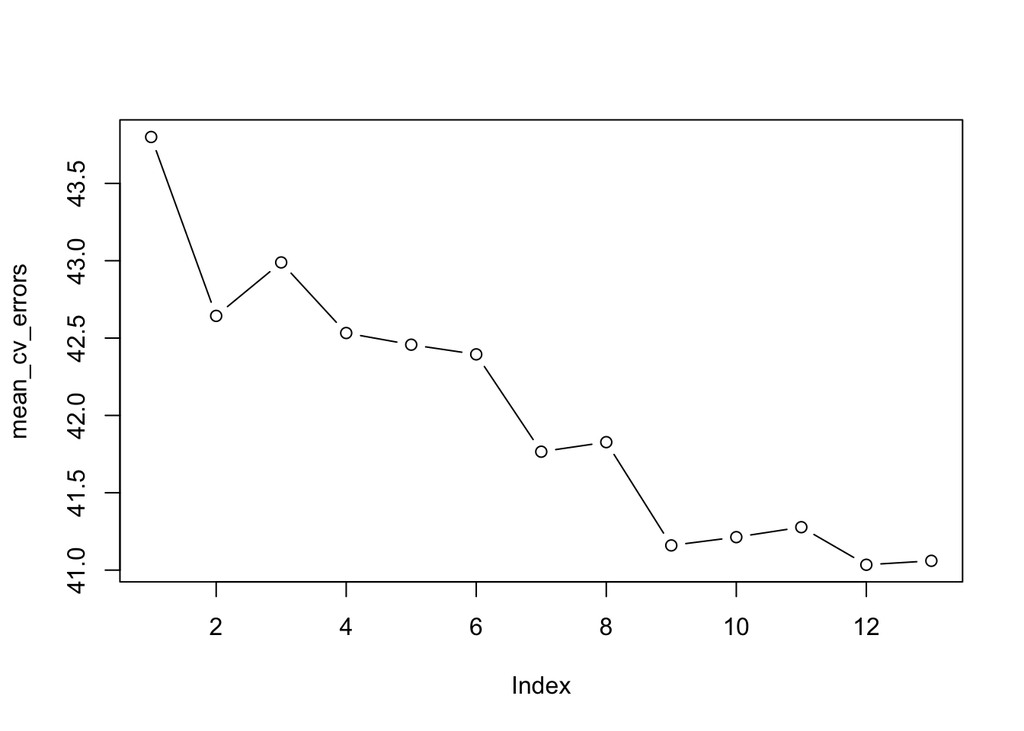

```r
mean_cv_errors <- colMeans(cv_errors)
plot(mean_cv_errors,type="b")
```

```r
final_best <- regsubsets(crim~.,data=Boston,nvmax=13)
coef(final_best,11)
```

```
##   (Intercept)            zn         indus           nox            rm
##  17.096652918   0.044858511  -0.069176572 -10.458590328   0.445708393
##           dis           rad           tax       ptratio         black
##  -0.997154027   0.583934313  -0.003454533  -0.265327998  -0.007599276
##         lstat          medv
##   0.127214918  -0.204431117
```

Second, ridge regression with cross validation to estimate test error:

```r
mean(crim)
```

```
## [1] 3.613524
```

```r
train <- (crim<3.6)
test <- !train
Boston.train <- Boston[train,]
Boston.test <- Boston[test,]
crim.test=crim[test]
```

```r
x<-model.matrix(crim~.,Boston)[,-1]
y<-Boston$crim
```

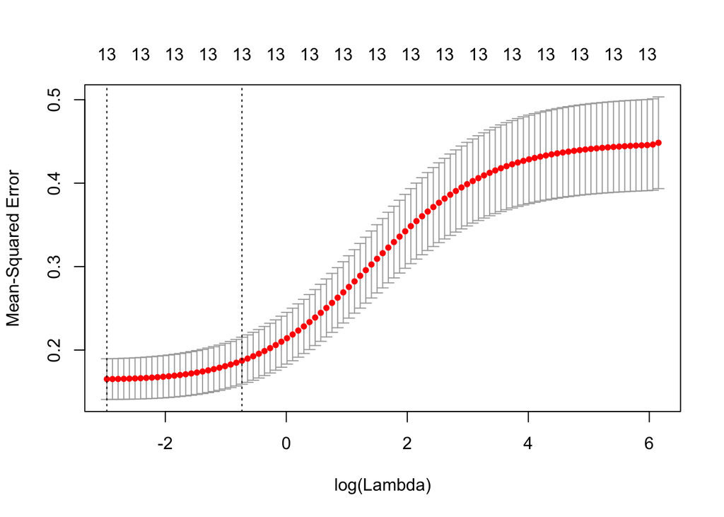

```r
library(glmnet)
grid=10^seq(10,-2,length=100)
ridge.mod=glmnet(x,y,alpha=0,lambda=grid)

set.seed(1)
cv.out <- cv.glmnet(x[train,],y[train],alpha=0)
plot(cv.out)
```

```r
bestlam <- cv.out$lambda.min
bestlam
```

```
## [1] 0.05152784
```

```r
ridge.pred <- predict(ridge.mod,s=bestlam,newx=x[test,])
mean((ridge.pred-crim.test)^2)
```

```
## [1] 148.5272
```

```r
out <- glmnet(x,y,alpha=0)
predict(out,type="coefficients",s=bestlam)
```

```
## 14 x 1 sparse Matrix of class "dgCMatrix"
##                        1
## (Intercept)  9.063048666
## zn           0.033002416
## indus       -0.082046152
## chas        -0.737684583
## nox         -5.393098508
## rm           0.335972073
## age          0.001962473
## dis         -0.702123643
## rad          0.422779055
## tax          0.003400607
## ptratio     -0.135911587
## black       -0.008483285
## lstat        0.142613436
## medv        -0.139604127
```